# Statistical Analyses for measuring the impact of COVID-19 Vaccine Misinformation on COVID-19 Vaccine Acceptance

This notebook covers all statistical models that generate results and figures in the main paper and supplementary. Transformed survey data are used.

We use [pystan](https://pystan.readthedocs.io/en/latest/) package, which is the Python implementation of the [Stan](https://mc-stan.org/) platform for statistical modeling. This package allows us to perform full Bayesian inference using Hamiltonian Monte Carlo via No-U-Turn Sampler (NUTS).

For brevity, the analysis in this notebook looks at the UK, and can be easily repeated for the US. We begin by importing the processed data for the UK (see `import_data.ipynb` for more details). The `src/utils.py` file provides many helper functions which we will frequently use to generate tables and figures for the paper. All models in this notebook can be found in `src/models.py`, but their `stan` code have been written out here to aid model description.

```python
%matplotlib inline
import src.utils as ut
import src.models as mo
OUT_DIR = './out/'
COUNTRY = 'uk' # change this variable to 'us' to perform analyses for the US
```

```python
df, dd = ut.import_transformed_data('dat/orb_%s'%COUNTRY)
```

## Overview of the Study

The primary objective of this paper is to study if there is a relationship between exposure to misinformation about COVID-19 vaccines to the intent to vaccinate. If there is, we are interested in quantifying the causal impact of such exposure on intent. To that end, we conducted nationally-representative surveys in the United Kingdom (UK) and United States (US) in September 2020 designed as a [randomized control trial](https://en.wikipedia.org/wiki/Randomized_controlled_trial), wherein respondents are divided into two groups, denoted by $G$: a Treatment group exposed to misinformation i.e. $G=T$ and a Control group exposed to factual information i.e.$G=C$. Respondent's vaccine intent is queried pre-exposure, referred to as $W$, and post-exposure, referred to as $Y$. In all, the study surveyed 8001 people: 3000 (3001) treatments in the UK (US) and 1000 controls in both countries. The survey flow is as follows:

1. **Query for vaccine intent:** $W$ [SELF] *If a new coronavirus (COVID-19) vaccine became available, would you accept the vaccine for yourself?*
2. **Query for vaccine intent:** $W$ [OTHERS] *If a new coronavirus (COVID-19) vaccine became available, would you accept the vaccine if it meant protecting friends, family, or at-risk groups?*
3. **Query for covariates:** $X$ such as amount of daily social media usage, or trust in different sources of information regarding COVID-19.
4. **Expose to 5 pieces if (mis)information** depending on random group assignment $G=T$ or $G=C$.
5. **Requery for vaccine intent:** $Y$ [SELF] *If a new coronavirus (COVID-19) vaccine became available, would you accept the vaccine for yourself?*
6. **Requery for vaccine intent:** $Y$ [OTHERS] *If a new coronavirus (COVID-19) vaccine became available, would you accept the vaccine if it meant protecting friends, family, or at-risk groups?*
7. **Query perceptions of exposed content:** $X$ for each image whether: (1) it raised their vaccination intent; (2) they agreed with the information presented; (3) they found the information to be trustworthy; (4) they were likely to fact-check; and (5) they were likely to share the image with friends or followers.
8. **Query for socio-demographic characteristics:** $X$ such as age, gender, highest education level, employment type, religious affiliation, ethnicity, income level and political affiliation.

For the full questionnaire of the study, please consult `doc/orb_questionnaire.pdf`.

## Overview of the Analyses

There are 3 main objectives of this study:

1. To see if there exists---and quantify---a causal link between exposure to misinformation on vaccine intent. **This is often referred to as (average) treatment effects.**
2. To determine if these effects are heterogeneous depending on certain attributes of the respondents, such as (a) the amount of social media usage, (b) their trust in sources of COVID-19 information, (c) other socio-demographic characteristics---as certain groups may be more or less robust to misinformation exposure. **This is often referred to as heterogeneous treatment effects (HTE).**
3. To study what makes certain misinformation more powerful than others, with the hopes of guiding better public health communication strategies.

For a full description of the analyses, please consult the *Introduction* section of the paper.

## Overview of Statistics

Here, we briefly describe the statistics used to conduct the above analyses, a full description of which can be found in the *Methods* section of the paper. In particular, see *Methods: Estimating treatment effects* and *Methods: Estimating image impact*.

### (Average) Treatment Effects

As noted in the paper, vaccine acceptance is a 4-class ordered variable going from $Y=1$ "Yes, definitely" to $Y=4$ "No, definitely not". Therefore, it is not meaningful to compute an expectation of the outcome, conditioned on treatment. Therefore, we consider computing the conditional probability mass function (PMF) of $Y$ instead ([Boes 2013](https://link.springer.com/article/10.1007/s00181-010-0354-y)) and define the following statistic:

$$\Delta(y)\equiv P(Y=y|G=T)-P(Y=y|G=C).$$

If $\Delta(y)>0$ ($\Delta(y)<0$), then the treatment induces an average individual with vaccine intent y to not change their vaccine intent (to change their vaccine intent)---relative to control. Alternately, $100\times\Delta(y)$ indicates the percentage point change in the number of people with intent y post exposure to misinformation, relative to factual information.

We remark that it is likely that the treatment effect will differ depending on the pre-exposure vaccine intent of an individual. Say, those with a very strong intent may not be swayed as much by information exposure. Correspondingly, we also define a treatment effect conditioned on pre-exposure intent:

$$\Delta_W(y;w)\equiv P(Y=y|W=w,G=T)-P(Y=y|W=w,G=C).$$

If $\Delta_W(y;w)>0$ ($\Delta_W(y;w)<0$), then the treatment induces an average individual to (not) change their vaccine intent from $w$ to $y$---relative to control. Alternately, $100\times\Delta_W(y;w)$ indicates the percentage point rise or drop in the number of people with prior intent $w$ who change it to $y$ post exposure to misinformation, relative to factual information.

### Heterogeneous Treatment Effects

We consider a number of respondent covariates $X$ in this study, and to compute conditional treatment effects as in above would lead to too many statistics, making them much harder to interpret. However, some progress can be made if we consider two changes.

First: instead of using the conditional PMF to judge causal effects at the outcome level $Y$, consider the conditional cumulative distribution instead. More precisely, consider the causal effect at the *latent* level of the log of cumulative odds ratio ([Volfovsky et al. 2015](https://arxiv.org/abs/1501.01234)): $\theta(g,x;y)=-\log\left(\frac{P(Y\le y|G=g,X=x)}{P(Y>y|G=g,X=x)}\right)$. The larger this value is, for any given $y\in\{1,2,3,4\}$, the larger is the hesitancy to vaccinate for individual $x$ under treatment $g$.

Second: since we are interested in finding whether treatment affects certain groups differentially, we can define some reference group $x_0$ against which we are comparing the effect for a group of interest $x$. That is, let $$\eta(g,x;x_0)\equiv\theta(g,x;y)-\theta(g,x_0;y).$$

Note that we have dropped the reference to $y$ on the LHS, for reasons that shall soon become clear, which has the convenience of having to consider only one causal statistic per covariate. Altogether, this leads to the causal statistic: $$\Delta_X(x;x_0)\equiv\eta(T,x;x_0)-\eta(C,x;x_0).$$

If $\Delta_X(x;x_0)>0$ ($\Delta_X(x;x_0)<0$), then the treatment makes an individual of group $x$ more (less) likely to move from lower vaccine hesitancy to a higher one when compared to an individual of group $x_0$---relative to control. If $\eta(g,x;x_0)>0$ ($\eta(g,x;x_0)<0$), then the exposure in group $g$ makes an individual of group $x$ more (less) likely to move from lower vaccine hesitancy to a higher one when compared to an individual of group $x_0$.

This allows us to measure the causal effect of $G$ on $Y$ (while controlling for $W$ for statistical precision). (See the "Statistical Methods" section of the paper for a full description of models and statistics we consider.)

### Image Impact Weights

Having queried for respondent's perceptions of the 5 images they were exposed to under condition $G=g$, one can learn the weights of each image in terms of contribution to lowering vaccine intent, post-exposure. We refer to this statistic as $\gamma_{k}^g\in\mathbb{R}_{\ge 0}$, such that $\sum_{k=1}^5\gamma_k^g =1$.

## Overview of Bayesian Models

We pursue a Bayesian modeling strategy to estimate all of the above statistics, a full description of which can be found in the *Methods* section of the paper. In particular, see *Methods: Estimating treatment effects; Bayesian ordered logistic regression framework* and *Methods: Estimating image impact*.

### Treatment Effects

Since vaccine intent is an ordered variable, the treatment may have montonic effects on intent to vaccinate. To this end, $W$ is modelled as a monotonic ordered covariate ([Bürkner & Charpentier 2020](https://bpspsychub.onlinelibrary.wiley.com/doi/full/10.1111/bmsp.12195)). We use ordered logistic regression ([McCullagh 1980](https://rss.onlinelibrary.wiley.com/doi/abs/10.1111/j.2517-6161.1980.tb01109.x)) to model $Y$, conditional on $G$, $W$ and covariates $X$:

$$W(i)\sim \mathrm{OrderedLogistic}(0, (\kappa_1,\kappa_2,\kappa_3)),$$$$Y(i)|G(i)=g,W(i),X(i) \sim \mathrm{OrderedLogistic}\left(\left[\beta_W^g\sum_{j=1}^{W(i)-1}\delta_j^g\right]+f(X(i);\beta_X^g), (\alpha_1^g,\alpha_2^g,\alpha_3^g)\right),$$

where the first term controls for pre-exposure intent $W$, and the function $f$ accounts for contributions of the covariates $X$. Given the form of the ordered Logistic distribution here implies a proportional-odds assumption, i.e., $\theta(g,x;y)$ is independent of $y$. In other words, conditioning on some covariate $x$ shifts the entire latent space of the log ORs by a uniform amount. This permits the use of one statistic per covariate of interest.

Given the above model definition, one can provide definitions of the above statistics in terms of the model parameters. Let $\sigma(x)=\frac{1}{1+\exp(-x)}$ be the Logistic sigmoid function. Then define:

$$\mu(w)\equiv P(W=w)=\sigma(\kappa_w)-\sigma(\kappa_{w-1}),$$$$\rho(g;y,w)\equiv P(Y=y|W=w,G=g)=\sigma\left(\alpha_y^g-\beta_W^g\sum_{j=1}^{w-1}\delta_j^g\right)-\sigma\left(\alpha_{y-1}^g-\beta_W^g\sum_{j=1}^{w-1}\delta_j^g\right).$$

Which leads to the causal statistics: $$\Delta_W(y;w)=\rho(T;y,w,)-\rho(C;y,w)$$ $$\Delta(y)=\sum_{w=1}^4\left(\rho(T;y,w,)-\rho(C;y,w)\right)\mu(w)$$

For HTEs, we assume the function $f$ to take a linear form in all covariates of interest, i.e. $f(X(i); \beta_X^g(i))=f\left(\{X_1(i),X_2(i),\cdots X_k(i)\}; \beta_X^g(i)\right)=\sum_{j=1}^k\beta^g_{X_j(i)}$ if there are $k$ categorical covariates. Due to this linearity, $\eta$'s can be estimated for each covariate separately, and then added up. Alternately, we may only consider marginal effects, i.e. one covariate $x$ at a time, in which case

$$\eta(g,x;x_0)=\beta^g_x-\beta^g_{x_0}$$$$\implies \Delta(x;x_0)=(\beta^T_x-\beta^C_x)-(\beta^T_{x_0}-\beta^C_{x_0})$$

### Image Impact

Let $X(i)$ refer to the $5\times 5$ matrix where $X_{jk}(i)\in\{-2,-1,0,1,2\}$ refers to the ith individual's [Likert-rating](https://en.wikipedia.org/wiki/Likert_scale) on the jth image-metric for the kth image. Then, the model definition is very similar to when pursuing heterogeneous treatment effects analysis, except the function of covariates now corresponds to an aggregation of ratings across images and image-metrics: $$Y(i)|G(i)=g,W(i),X(i) \sim \mathrm{OrderedLogistic}\left(\left[\beta_W^g\sum_{j=1}^{W(i)-1}\delta_j^g\right]+\sum_{j=1}^5\sum_{k=1}^5\beta_j^gX_{jk}(i)\gamma_k^g, (\alpha_1^g,\alpha_2^g,\alpha_3^g)\right).$$

This allows one to gauge both (a) which images have the most impact in group $G=g$ (from $\gamma_k^g$) and (b) which image metrics have the most impact in group $G=g$ (from $\beta_j^g\in\mathbb{R}$).

### Model Inference

As mentioned above, Bayesian inference is performed to infer posterior distributions on all model parameters, and statistics---percentages, log odds-ratios, parameters---described above. While the mean of the statistics can be used to judge the effect size, we also provide 95% percentile posterior credible intervals (in parantheses next to mean estimates) to judge probable values of the effect size, and thus some sense of "significance" of the effect. Any Bayesian model requires placing prior distributions on model parameters. We make use of regularizing hierarchical priors wherever possible, to prevent detection of spurious effects. For full details, refer to specific model details in the *Methods* section. We employ 4 chains of 2000 iterations, i.e. 4000 samples excluding warmup, and will also report diagnostics below to ensure that the HMC chains are converging as expected.

## Running the Models

### (Average) Treatment Effects

First, we will run the model to estimate causal effects. **This contributes to Table 1, Figure 2, and Supplementary Table 2 of the paper.** Let us print the `stan` model code for this model:

```python
print(mo.model_impact_causal(df, code_only=True))
```

```
                data {
                    int<lower=1> n; //number of data points
                    int<lower=1> m; //number of conditions
                    int<lower=2> k; //number of outcomes
                    int<lower=1,upper=m> x_cond[n]; //treatment group
                    int<lower=1,upper=k> y_pre[n]; //pre-exposure outcome
                    int<lower=1,upper=k> y_post[n]; //post-exposure outcome
                }
                parameters {
                    real mu_beta;
                    real beta[m];
                    vector<lower=0>[k-1] mu_delta;
                    simplex[k-1] delta[m];
                    vector[k-1] mu_alpha;
                    ordered[k-1] alpha[m];
                    ordered[k-1] alpha_pre;
                }
                model {
                    mu_beta ~ normal(0, 1.000000);
                    mu_alpha ~ normal(0, 1.000000);
                    mu_delta ~ exponential(1.000000);
                    for (i in 1:m){
                        beta[i] ~ normal(mu_beta, 1.000000);
                        alpha[i] ~ normal(mu_alpha, 1.000000);
                        delta[i] ~ dirichlet(mu_delta);
                    }
                    alpha_pre ~ normal(0, 1.000000);
                    for (i in 1:n){
                        y_pre[i] ~ ordered_logistic(0, alpha_pre);
                        y_post[i] ~ ordered_logistic(beta[x_cond[i]]*sum(delta[x_cond[i]][:y_pre[i]-1]), alpha[x_cond[i]]);
                    }
                }
```

Here, `y_pre` refers to $W$ and `y_post` to $Y$. Now, we fit the model to data for the "SELF" type question, which queries for vaccine intent to protect oneself.

```python
fit_impact_causal_self = mo.model_impact_causal(df)
```

```
INFO:pystan:COMPILING THE C++ CODE FOR MODEL anon_model_a8236a2b009a64b21fe1f83e6eff3e14 NOW.
```

This model seems to have run without any serious `stan` warnings about the NUTS sampler misbehaving. We use the `stats()` function in `src/utils.py` to get a quick summary of the posterior estimates of main model parameters. In particular, we are looking for well-mixed chains, that is the Rhat statistic to be close to 1, and the effective sample size (ESS) to be a large value---at least 100 per chain ([Vehtari et al. 2020](http://www.stat.columbia.edu/~gelman/research/published/Vehtari_etal_2020_rhat_ess.pdf)).

```python
fit2diags_impact_causal = ut.stats(fit_impact_causal_self, save=OUT_DIR+'1_%s_impact_causal_self_diags'%COUNTRY)
print(fit2diags_impact_causal)
```

```
              Mean  2.5%  97.5%   ESS  Rhat
mu_beta       5.66  4.51   6.83  5024   1.0
beta[1]       8.72  7.98   9.54  2397   1.0
beta[2]       8.25  7.76   8.78  2865   1.0
mu_delta[1]   1.77  0.37   4.03  3996   1.0
mu_delta[2]   1.51  0.31   3.55  4435   1.0
mu_delta[3]   1.43  0.29   3.37  4253   1.0
delta[1,1]    0.42  0.38   0.47  2952   1.0
delta[2,1]    0.38  0.35   0.41  2943   1.0
delta[1,2]    0.33  0.27   0.38  4806   1.0
delta[2,2]    0.31  0.27   0.34  4891   1.0
delta[1,3]    0.25  0.18   0.32  3177   1.0
delta[2,3]    0.32  0.27   0.36  3020   1.0
mu_alpha[1]   1.22  0.09   2.32  5146   1.0
mu_alpha[2]   3.39  2.20   4.57  4908   1.0
mu_alpha[3]   4.82  3.64   5.98  5446   1.0
alpha[1,1]    2.21  1.94   2.49  3699   1.0
alpha[2,1]    1.42  1.30   1.54  4745   1.0
alpha[1,2]    5.87  5.43   6.33  3608   1.0
alpha[2,2]    4.32  4.11   4.54  4004   1.0
alpha[1,3]    8.07  7.50   8.68  3276   1.0
alpha[2,3]    6.38  6.09   6.67  4478   1.0
alpha_pre[1]  0.16  0.10   0.23  5332   1.0
alpha_pre[2]  1.82  1.73   1.90  7538   1.0
alpha_pre[3]  2.75  2.62   2.88  6421   1.0
```

$\hat{R}$ appears to be close to $1$, and the smallest ESS is $2397$, so seems like we're doing good. Next, we output the inferred statistics:

```python
fit2stats_impact_causal = ut.stats_impact_causal(fit_impact_causal_self, save=OUT_DIR+'1_%s_impact_causal_self_stats'%COUNTRY)
ut.unstack_df(ut.collapse_df(fit2stats_impact_causal['ATE'], perc=True))
```

|  | Yes, definitely | Unsure, lean yes | Unsure, lean no | No, definitely not |
| --- | --- | --- | --- | --- |
| Control | 54.8 (52.6, 57.1) | 30.9 (28.6, 33.2) | 8.5 (7.0, 10.2) | 5.8 (4.6, 7.0) |
| Treatment | 48.6 (46.9, 50.2) | 31.1 (29.5, 32.6) | 11.3 (10.2, 12.4) | 9.1 (8.2, 10.0) |
| Treatment-Control | -6.2 (-8.5, -3.9) | 0.2 (-2.5, 2.8) | 2.7 (1.0, 4.5) | 3.3 (2.0, 4.6) |
| Baseline | 54.1 (52.5, 55.7) | 31.9 (30.5, 33.3) | 8.0 (7.1, 8.9) | 6.0 (5.3, 6.8) |

The baseline distribution suggests that as of September 2020, about 54.1% people in the UK would "definitely" take a COVID-19 vaccine to protect themselves, while 6.0% will "definitely not", the rest being unsure in the middle. A look at the control and treatment distributions shows how people's intent changes post exposure, with the row "Treatment-Control" indicating the statistic $\Delta(y)$. That is, there's a fall in about 6.2% people who were definitely sure about accepting a vaccine post exposure to misinformation, relative to factual information. Similarly, there's a rise in those saying they definitely won't by about 3.3%.

We can also compute the statistic $\Delta_W(y;w)$:

```python
ut.unstack_df(ut.collapse_df(fit2stats_impact_causal['CATE'], perc=True))
```

|  |  | Yes, definitely | Unsure, lean yes | Unsure, lean no | No, definitely not |
| --- | --- | --- | --- | --- | --- |
| Control | Yes, definitely | 90.0 (87.4, 92.3) | 9.7 (7.4, 12.2) | 0.3 (0.2, 0.4) | 0.0 (0.0, 0.1) |
|  | Unsure, lean yes | 18.7 (14.8, 22.8) | 71.1 (66.6, 75.4) | 9.0 (6.5, 11.9) | 1.3 (0.7, 2.0) |
|  | Unsure, lean no | 1.4 (0.8, 2.3) | 33.1 (24.6, 41.9) | 47.8 (39.7, 56.0) | 17.8 (11.7, 25.4) |
|  | No, definitely not | 0.2 (0.1, 0.3) | 5.6 (2.7, 9.7) | 28.8 (19.2, 39.7) | 65.5 (51.8, 77.1) |
| Treatment | Yes, definitely | 80.5 (78.5, 82.3) | 18.2 (16.5, 20.0) | 1.2 (0.9, 1.4) | 0.2 (0.1, 0.2) |
|  | Unsure, lean yes | 15.4 (13.3, 17.5) | 61.3 (58.6, 64.0) | 19.6 (17.4, 21.8) | 3.8 (2.9, 4.7) |
|  | Unsure, lean no | 1.5 (1.1, 1.9) | 19.6 (15.8, 23.7) | 46.4 (42.3, 50.6) | 32.5 (27.3, 37.9) |
|  | No, definitely not | 0.1 (0.1, 0.2) | 1.9 (1.1, 2.9) | 11.5 (7.6, 16.0) | 86.5 (81.1, 91.1) |
| Treatment-Control | Yes, definitely | -9.6 (-12.5, -6.4) | 8.5 (5.5, 11.4) | 0.9 (0.6, 1.2) | 0.1 (0.1, 0.2) |
|  | Unsure, lean yes | -3.3 (-8.1, 1.1) | -9.8 (-14.8, -4.5) | 10.6 (7.1, 14.0) | 2.5 (1.4, 3.6) |
|  | Unsure, lean no | 0.1 (-0.9, 0.9) | -13.5 (-22.9, -4.3) | -1.3 (-10.4, 7.7) | 14.8 (5.9, 22.9) |
|  | No, definitely not | -0.0 (-0.2, 0.1) | -3.7 (-7.8, -0.7) | -17.3 (-28.6, -6.9) | 21.0 (8.1, 35.2) |

This table is difficult to parse, and so we make use of a helper plotting function `plot_stats()` in `src/utils.py` to visualize the treatment effects.

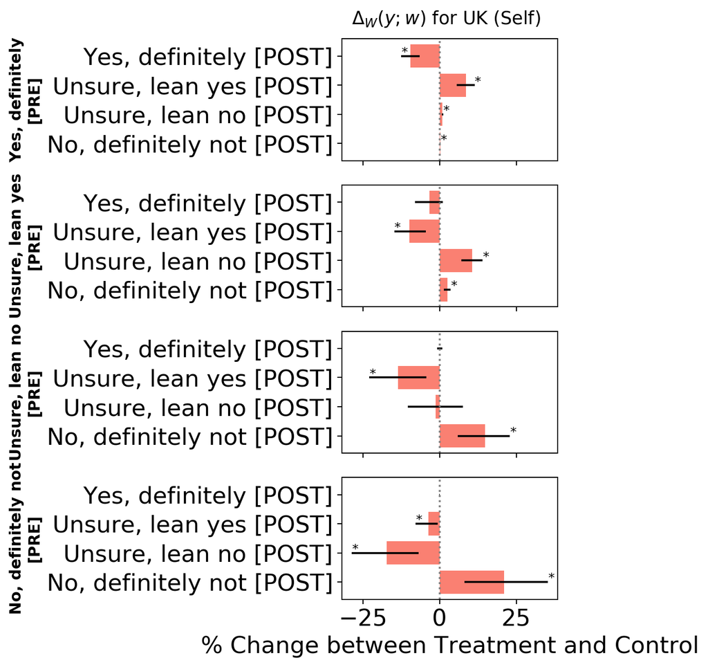

```python
ut.plot_stats(fit2stats_impact_causal['CATE'].loc['Treatment-Control']*100, oddsratio=False, title='$\\Delta_W(y;w)$ for %s (Self)'%(COUNTRY.upper()), xlabel='% Change between Treatment and Control', tick_suffix=' [POST]', label_suffix='\n[PRE]', factor=0.5, title_loc=-0.08, bars=True, highlight=True)
```

Evidently, there's a downward trend across categories, that is the treatment lowers intent to vaccinate for all pre-exposure intent groups. We can repeat the above analysis for the "OTHERS" type question.

```python
fit_impact_causal_others = mo.model_impact_causal(df, kind='others')
```

```
INFO:pystan:COMPILING THE C++ CODE FOR MODEL anon_model_a8236a2b009a64b21fe1f83e6eff3e14 NOW.
```

```python
fit2diags_impact_causal_others = ut.stats(fit_impact_causal_others, save=OUT_DIR+'1_%s_impact_causal_others_diags'%COUNTRY)
```

```python
fit2stats_impact_causal_others = ut.stats_impact_causal(fit_impact_causal_others, save=OUT_DIR+'1_%s_impact_causal_others_stats'%COUNTRY)
```

```python
ut.unstack_df(ut.collapse_df(fit2stats_impact_causal_others['ATE'], perc=True))
```

|  | Yes, definitely | Unsure, lean yes | Unsure, lean no | No, definitely not |
| --- | --- | --- | --- | --- |
| Control | 61.5 (59.3, 63.7) | 25.6 (23.4, 27.9) | 7.2 (5.8, 8.7) | 5.7 (4.6, 6.9) |
| Treatment | 55.7 (54.1, 57.4) | 27.9 (26.4, 29.4) | 9.6 (8.6, 10.6) | 6.8 (6.0, 7.6) |
| Treatment-Control | -5.7 (-7.9, -3.5) | 2.3 (-0.3, 4.8) | 2.3 (0.7, 4.0) | 1.1 (-0.1, 2.3) |
| Baseline | 63.7 (62.2, 65.1) | 24.7 (23.4, 26.1) | 7.0 (6.2, 7.8) | 4.5 (3.9, 5.2) |

Interestingly, looking at the baseline intent here with 63.7% saying "definitely", it is much higher than what we saw when people were asked about the intent to protect themselves (above). This might have implications for altruistic campaigns promoting COVID-19 vaccinations. We can similarly compute the treatment effects $\Delta_W(y;w)$ for the "OTHER" type question, which shows similar trends as above. Let's generate those figures for a simple visual interpretation by using a helper function.

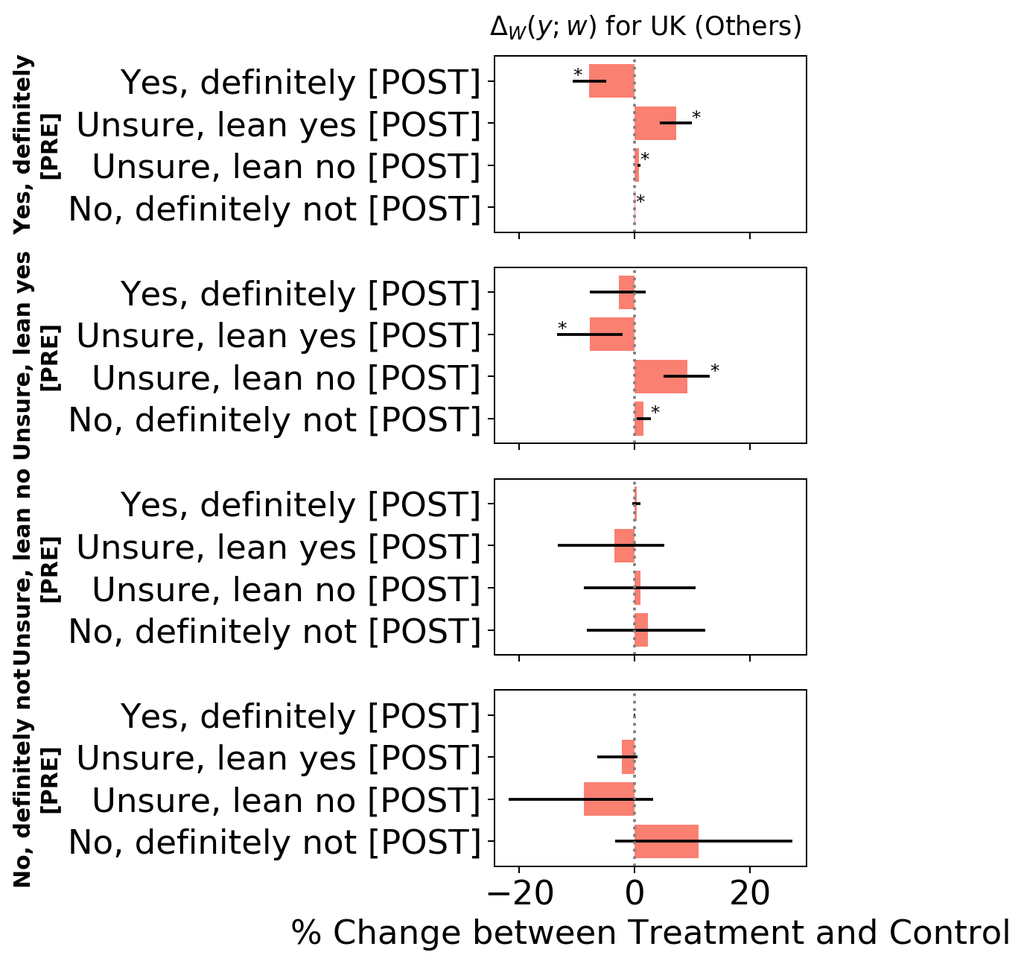

```python
ut.plot_stats(fit2stats_impact_causal_others['CATE'].loc['Treatment-Control']*100, oddsratio=False, title='$\\Delta_W(y;w)$ for %s (Others)'%(COUNTRY.upper()), xlabel='% Change between Treatment and Control', tick_suffix=' [POST]', label_suffix='\n[PRE]', factor=0.5, title_loc=-0.08, bars=True, highlight=True)
```

It's evident that overall, respondents tend to transition from higher vaccine acceptance categories to lower ones upon exposure to misinformation, relative to exposure to factual-information. An alternate representation of the entire above analysis is to draw Sankey plots which show the "flow" of people pre- and post-exposure to information.

```python
ut.plot_causal_flow(fit2stats_impact_causal_self)
```

[interactive chart not shown]

### Heterogeneous Treatment Effects

Once we have established that misinformation does impact vaccine acceptance, we can look at the socio-econo-demographic determinants of this hesitancy, and if certain groups of people might be more susceptible to COVID-19 vaccine misinformation. **This contributes to Figure 3, Supplementary Figures 1, 2, 3, 4 and Supplementary Tables 3, 4, 5, 6 of the paper.** Let us print the `stan` model code for this model:

```python
print(mo.model_socdem(df, dd, code_only=True))
```

```
Dataframe of size: (4000, 11)

                            data {
                                int<lower=1> n; //number of data points
                                int<lower=1> m; //number of conditions
                                int<lower=2> k; //number of outcomes
                                int<lower=1,upper=m> x_cond[n]; //treatment group
                                int<lower=1,upper=k> y_pre[n]; //pre-exposure outcome
                                int<lower=1,upper=k> y_post[n]; //post-exposure outcome
                                int<lower=1> k_Age;
int<lower=1,upper=k_Age> Age[n];
int<lower=1> k_Gender;
int<lower=1,upper=k_Gender> Gender[n];
int<lower=1> k_Education;
int<lower=1,upper=k_Education> Education[n];
int<lower=1> k_Employment;
int<lower=1,upper=k_Employment> Employment[n];
int<lower=1> k_Religion;
int<lower=1,upper=k_Religion> Religion[n];
int<lower=1> k_Political;
int<lower=1,upper=k_Political> Political[n];
int<lower=1> k_Ethnicity;
int<lower=1,upper=k_Ethnicity> Ethnicity[n];
int<lower=1> k_Income;
int<lower=1,upper=k_Income> Income[n];
                            }
                            parameters {
                                real beta_Age[m,k_Age];real mu_beta_Age[k_Age];
real beta_Gender[m,k_Gender];real mu_beta_Gender[k_Gender];
real beta_Education[m,k_Education];real mu_beta_Education[k_Education];
real beta_Employment[m,k_Employment];real mu_beta_Employment[k_Employment];
real beta_Religion[m,k_Religion];real mu_beta_Religion[k_Religion];
real beta_Political[m,k_Political];real mu_beta_Political[k_Political];
real beta_Ethnicity[m,k_Ethnicity];real mu_beta_Ethnicity[k_Ethnicity];
real beta_Income[m,k_Income];real mu_beta_Income[k_Income];
                                real mu_beta;
                                real beta[m];
                                vector<lower=0>[k-1-0] mu_delta;
                                simplex[k-1-0] delta[m];
                                vector[k-1] mu_alpha;
```

[output cut: 23 more lines]

```
		beta_Ethnicity[i][j] ~ normal(mu_beta_Ethnicity[j], 1.000000);
mu_beta_Income ~ normal(0, 1.000000);for (i in 1:m)
	for (j in 1:k_Income)
		beta_Income[i][j] ~ normal(mu_beta_Income[j], 1.000000);
                                mu_beta ~ normal(0, 1.000000);
                                mu_alpha ~ normal(0, 1.000000);
                                mu_delta ~ exponential(1.000000);
                                for (i in 1:m){
                                    beta[i] ~ normal(mu_beta, 1.000000);
                                    alpha[i] ~ normal(mu_alpha, 1.000000);
                                    delta[i] ~ dirichlet(mu_delta);
                                }
                                for (i in 1:n)
                                    y_post[i] ~ ordered_logistic(beta[x_cond[i]]*sum(delta[x_cond[i]][:y_pre[i]-1-0]) + beta_Age[x_cond[i],Age[i]] + beta_Gender[x_cond[i],Gender[i]] + beta_Education[x_cond[i],Education[i]] + beta_Employment[x_cond[i],Employment[i]] + beta_Religion[x_cond[i],Religion…
                            }
```

Next, we run the model, for both "SELF" and "OTHERS" type questions.

```python
fit_socdem_causal_self = mo.model_socdem(df, dd, kind='self')
```

```
INFO:pystan:COMPILING THE C++ CODE FOR MODEL anon_model_2bd5098854b8d558d311729c4a8c369c NOW.
```

```
Dataframe of size: (4000, 11)
```

```python
fit_socdem_causal_others = mo.model_socdem(df, dd, kind='others')
```

```
INFO:pystan:COMPILING THE C++ CODE FOR MODEL anon_model_2bd5098854b8d558d311729c4a8c369c NOW.
```

```
Dataframe of size: (4000, 11)
```

```python
diags_socdem_self = ut.stats(fit_socdem_causal_self, save=OUT_DIR+'2_%s_socdem_self_diags'%COUNTRY)
stats_socdem_self_or = ut.stats_socdem(fit_socdem_causal_self, dd, df, oddsratio=True, save=OUT_DIR+'2_%s_socdem_self_stats_OR'%COUNTRY)
stats_socdem_self_logor = ut.stats_socdem(fit_socdem_causal_self, dd, df, oddsratio=False, save=OUT_DIR+'2_%s_socdem_self_stats_logOR'%COUNTRY)
```

```python
diags_socdem_others = ut.stats(fit_socdem_causal_others, save=OUT_DIR+'2_%s_socdem_others_diags'%COUNTRY)
stats_socdem_others_or = ut.stats_socdem(fit_socdem_causal_others, dd, df, oddsratio=True, save=OUT_DIR+'2_%s_socdem_others_stats_OR'%COUNTRY)
stats_socdem_others_logor = ut.stats_socdem(fit_socdem_causal_others, dd, df, oddsratio=False, save=OUT_DIR+'2_%s_socdem_others_stats_logOR'%COUNTRY)
```

Finally, we plot the inferred statistics $\eta(T,x;x_0)$ (left), $\eta(C,x;x_0)$ (center) and $\Delta_X(x;x_0)$ (right) below. The reference demographic group is given by: male, 18-24, highest education, employed, Christian, Conservative/Republican, White, and highest income. The numbers on the right indicate number of samples in each demographic group.

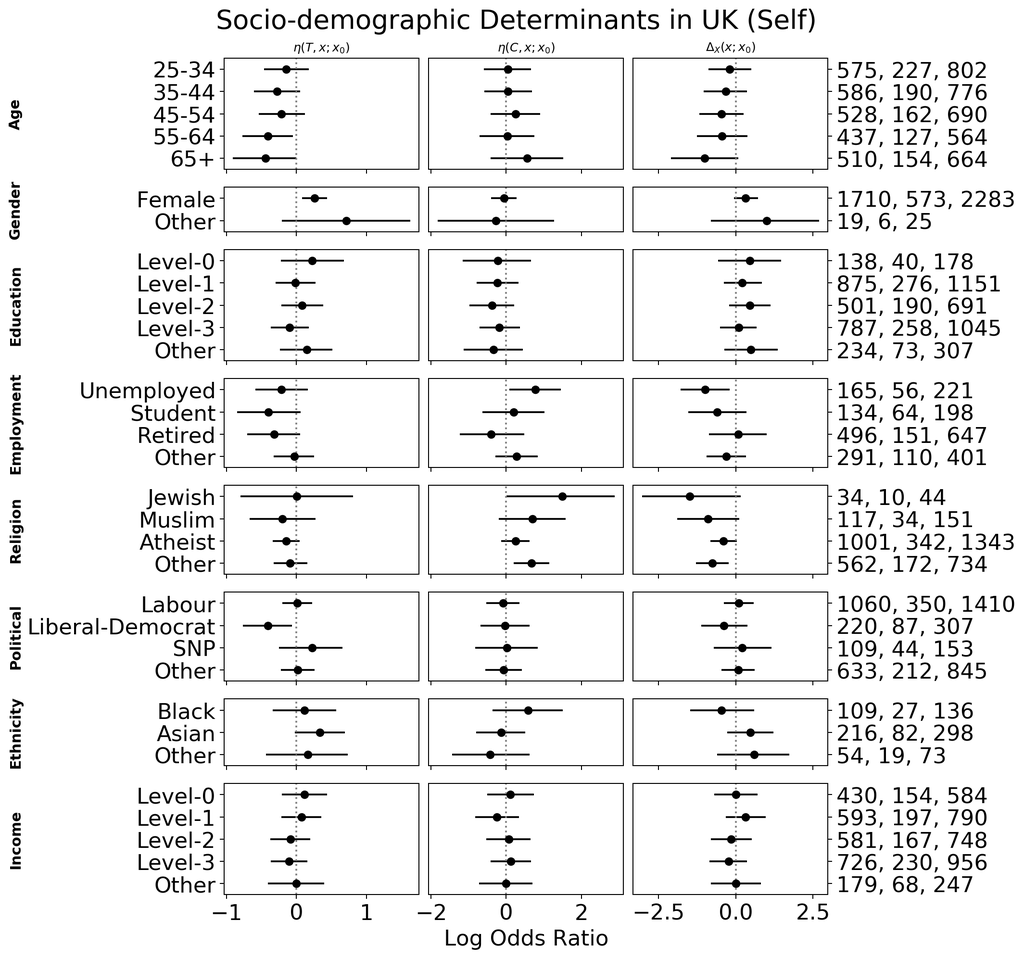

```python
ut.plot_stats([stats_socdem_self_logor.loc['Treatment'], stats_socdem_self_logor.loc['Control'], stats_socdem_self_logor.loc['Treatment-Control']], demos=True, oddsratio=False, title='Socio-demographic Determinants in %s (Self)'%(COUNTRY.upper()), subtitle=['$\\eta(T,x;x_0)$', '$\\eta(C,x;x_0)$', '$\\Delta_X(x;x_0)$'], xlabel='Log Odds Ratio', factor=0.4, titlesize=22, title_loc=-0.075, align_labels=True)
```

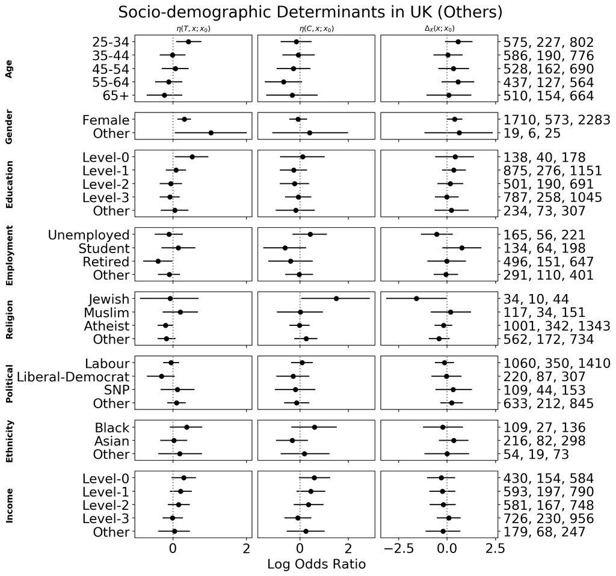

```python
ut.plot_stats([stats_socdem_others_logor.loc['Treatment'], stats_socdem_others_logor.loc['Control'], stats_socdem_others_logor.loc['Treatment-Control']], demos=True, oddsratio=False, title='Socio-demographic Determinants in %s (Others)'%(COUNTRY.upper()), subtitle=['$\\eta(T,x;x_0)$', '$\\eta(C,x;x_0)$', '$\\Delta_X(x;x_0)$'], xlabel='Log Odds Ratio', factor=0.4, titlesize=22, title_loc=-0.075, align_labels=True)
```

A quick comparison shows a lot of similarity between the two types of analyses, and thus for any subsequent analyses we utilise only one question, i.e. the "SELF" type question. A few trends become apparent above: in the UK, the older age groups appear to be more robust to misinformation exposure compared to 18-24 year olds, while females are less than males, and Liberal-Democrats more than Conservatives. Although the effect sizes and trends remain, they dilute when looking in contrast with exposure to factual information. For a deeper discussion, refer to the *Results* section of the paper.

#### Social media use

Next, we consider whether the amount of time spent on social media daily can be a factor for heterogeneous effects. This is done while controlling for the socio-demographics mentioned above, i.e., the model simply adds more predictor variables corresponding to social media use. Let's print the `stan` code first:

```python
print(mo.model_socdem(df, dd, 'Social media', code_only=True))
```

```
Dataframe of size: (4000, 12)

                            data {
                                int<lower=1> n; //number of data points
                                int<lower=1> m; //number of conditions
                                int<lower=2> k; //number of outcomes
                                int<lower=1,upper=m> x_cond[n]; //treatment group
                                int<lower=1,upper=k> y_pre[n]; //pre-exposure outcome
                                int<lower=1,upper=k> y_post[n]; //post-exposure outcome
                                int<lower=1> k_Age;
int<lower=1,upper=k_Age> Age[n];
int<lower=1> k_Gender;
int<lower=1,upper=k_Gender> Gender[n];
int<lower=1> k_Education;
int<lower=1,upper=k_Education> Education[n];
int<lower=1> k_Employment;
int<lower=1,upper=k_Employment> Employment[n];
int<lower=1> k_Religion;
int<lower=1,upper=k_Religion> Religion[n];
int<lower=1> k_Political;
int<lower=1,upper=k_Political> Political[n];
int<lower=1> k_Ethnicity;
int<lower=1,upper=k_Ethnicity> Ethnicity[n];
int<lower=1> k_Income;
int<lower=1,upper=k_Income> Income[n];
int<lower=1> k_Social_media_usage;
int<lower=1,upper=k_Social_media_usage> Social_media_usage[n];
                            }
                            parameters {
                                real beta_Age[m,k_Age];real mu_beta_Age[k_Age];
real beta_Gender[m,k_Gender];real mu_beta_Gender[k_Gender];
real beta_Education[m,k_Education];real mu_beta_Education[k_Education];
real beta_Employment[m,k_Employment];real mu_beta_Employment[k_Employment];
real beta_Religion[m,k_Religion];real mu_beta_Religion[k_Religion];
real beta_Political[m,k_Political];real mu_beta_Political[k_Political];
real beta_Ethnicity[m,k_Ethnicity];real mu_beta_Ethnicity[k_Ethnicity];
real beta_Income[m,k_Income];real mu_beta_Income[k_Income];
real beta_Social_media_usage[m,k_Social_media_usage];real mu_beta_Social_media_usage[k_Social_media_usage];
                                real mu_beta;
                                real beta[m];
```

[output cut: 29 more lines]

```
		beta_Income[i][j] ~ normal(mu_beta_Income[j], 1.000000);
mu_beta_Social_media_usage ~ normal(0, 1.000000);for (i in 1:m)
	for (j in 1:k_Social_media_usage)
		beta_Social_media_usage[i][j] ~ normal(mu_beta_Social_media_usage[j], 1.000000);
                                mu_beta ~ normal(0, 1.000000);
                                mu_alpha ~ normal(0, 1.000000);
                                mu_delta ~ exponential(1.000000);
                                for (i in 1:m){
                                    beta[i] ~ normal(mu_beta, 1.000000);
                                    alpha[i] ~ normal(mu_alpha, 1.000000);
                                    delta[i] ~ dirichlet(mu_delta);
                                }
                                for (i in 1:n)
                                    y_post[i] ~ ordered_logistic(beta[x_cond[i]]*sum(delta[x_cond[i]][:y_pre[i]-1-0]) + beta_Age[x_cond[i],Age[i]] + beta_Gender[x_cond[i],Gender[i]] + beta_Education[x_cond[i],Education[i]] + beta_Employment[x_cond[i],Employment[i]] + beta_Religion[x_cond[i],Religion…
                            }
```

Next, we run the model. If one encounters a warning about reaching the maximum tree depth for the sampler, then the limit can be increased from 10 to higher values, such as 15 or 20.

```python
fit_social_causal = mo.model_socdem(df, dd, 'Social media', max_treedepth=15)
```

```
INFO:pystan:COMPILING THE C++ CODE FOR MODEL anon_model_91baf77b485f15c0f72e9f29215adeee NOW.
```

```
Dataframe of size: (4000, 12)
```

```python
diags_social = ut.stats(fit_social_causal, save=OUT_DIR+'3_%s_social_diags'%COUNTRY)
stats_social_or = ut.stats_socdem(fit_social_causal, dd, df, 'Social media', oddsratio=True, save=OUT_DIR+'3_%s_social_stats_OR'%COUNTRY)
stats_social_logor = ut.stats_socdem(fit_social_causal, dd, df, 'Social media', oddsratio=False, save=OUT_DIR+'3_%s_social_stats_logOR'%COUNTRY)
```

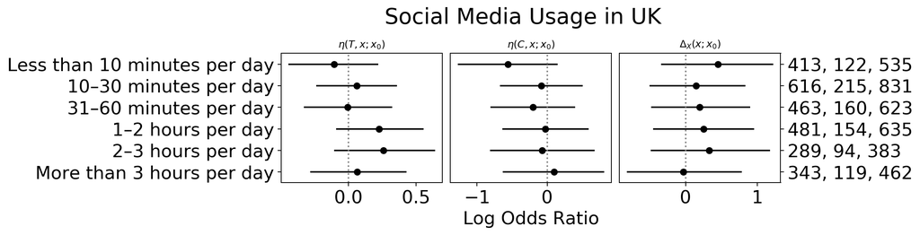

```python
ut.plot_stats([stats_social_logor.loc['Treatment'], stats_social_logor.loc['Control'], stats_social_logor.loc['Treatment-Control']], demos=False, oddsratio=False, title='Social Media Usage in %s'%(COUNTRY.upper()), subtitle=['$\\eta(T,x;x_0)$', '$\\eta(C,x;x_0)$', '$\\Delta_X(x;x_0)$'], xlabel='Log Odds Ratio', ylabel=False, factor=0.4, titlesize=22, title_loc=0.15)
```

Here, the baseline category $x_0$ refers no no social media use. There is no clear relationship between social media use and robustness to misinformation relative to factual information for the UK.

#### Source of COVID-19 Information that are Trusted

It has been shown that trust plays a very important role when it comes to accessing public health information. We can thus do a similar analysis to observe how having trust in different sources of information for COVID-19 may determine vaccine hesitancy and susceptibility to misinformation. Let's print the `stan` code, run the model, and visualise the statistics.

```python
print(mo.model_socdem(df, dd, 'Trust:', code_only=True))
```

```
Dataframe of size: (4000, 27)

                            data {
                                int<lower=1> n; //number of data points
                                int<lower=1> m; //number of conditions
                                int<lower=2> k; //number of outcomes
                                int<lower=1,upper=m> x_cond[n]; //treatment group
                                int<lower=1,upper=k> y_pre[n]; //pre-exposure outcome
                                int<lower=1,upper=k> y_post[n]; //post-exposure outcome
                                int<lower=1> k_Age;
int<lower=1,upper=k_Age> Age[n];
int<lower=1> k_Gender;
int<lower=1,upper=k_Gender> Gender[n];
int<lower=1> k_Education;
int<lower=1,upper=k_Education> Education[n];
int<lower=1> k_Employment;
int<lower=1,upper=k_Employment> Employment[n];
int<lower=1> k_Religion;
int<lower=1,upper=k_Religion> Religion[n];
int<lower=1> k_Political;
int<lower=1,upper=k_Political> Political[n];
int<lower=1> k_Ethnicity;
int<lower=1,upper=k_Ethnicity> Ethnicity[n];
int<lower=1> k_Income;
int<lower=1,upper=k_Income> Income[n];
int<lower=1> k_Trust_Television;
int<lower=1,upper=k_Trust_Television> Trust_Television[n];
int<lower=1> k_Trust_Radio;
int<lower=1,upper=k_Trust_Radio> Trust_Radio[n];
int<lower=1> k_Trust_Newspapers;
int<lower=1,upper=k_Trust_Newspapers> Trust_Newspapers[n];
int<lower=1> k_Trust_Govt_Briefings;
int<lower=1,upper=k_Trust_Govt_Briefings> Trust_Govt_Briefings[n];
int<lower=1> k_Trust_National_Health_Authorities;
int<lower=1,upper=k_Trust_National_Health_Authorities> Trust_National_Health_Authorities[n];
int<lower=1> k_Trust_International_Health_Authorities;
int<lower=1,upper=k_Trust_International_Health_Authorities> Trust_International_Health_Authorities[n];
int<lower=1> k_Trust_Healthcare_Workers;
int<lower=1,upper=k_Trust_Healthcare_Workers> Trust_Healthcare_Workers[n];
int<lower=1> k_Trust_Scientists;
```

[output cut: 119 more lines]

```
		beta_Trust_Other[i][j] ~ normal(mu_beta_Trust_Other[j], 1.000000);
mu_beta_Trust_None_of_these ~ normal(0, 1.000000);for (i in 1:m)
	for (j in 1:k_Trust_None_of_these)
		beta_Trust_None_of_these[i][j] ~ normal(mu_beta_Trust_None_of_these[j], 1.000000);
                                mu_beta ~ normal(0, 1.000000);
                                mu_alpha ~ normal(0, 1.000000);
                                mu_delta ~ exponential(1.000000);
                                for (i in 1:m){
                                    beta[i] ~ normal(mu_beta, 1.000000);
                                    alpha[i] ~ normal(mu_alpha, 1.000000);
                                    delta[i] ~ dirichlet(mu_delta);
                                }
                                for (i in 1:n)
                                    y_post[i] ~ ordered_logistic(beta[x_cond[i]]*sum(delta[x_cond[i]][:y_pre[i]-1-0]) + beta_Age[x_cond[i],Age[i]] + beta_Gender[x_cond[i],Gender[i]] + beta_Education[x_cond[i],Education[i]] + beta_Employment[x_cond[i],Employment[i]] + beta_Religion[x_cond[i],Religion…
                            }
```

```python
fit_trust_causal = mo.model_socdem(df, dd, 'Trust:', max_treedepth=20)
```

```
Dataframe of size: (4000, 27)
```

```
INFO:pystan:COMPILING THE C++ CODE FOR MODEL anon_model_3e49be5d3868cec13365428cdebd70df NOW.
```

```python
diags_trust_causal = ut.stats(fit_trust_causal, save=OUT_DIR+'4_%s_trust_causal_diags'%COUNTRY)
stats_trust_causal_or = ut.stats_socdem(fit_trust_causal, dd, df, 'Trust:', oddsratio=True, save=OUT_DIR+'4_%s_trust_causal_stats_OR'%COUNTRY)
stats_trust_causal_logor = ut.stats_socdem(fit_trust_causal, dd, df, 'Trust:', oddsratio=False, save=OUT_DIR+'4_%s_trust_causal_stats_logOR'%COUNTRY)
```

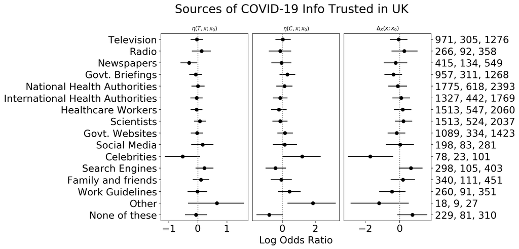

```python
ut.plot_stats([stats_trust_causal_logor.loc['Treatment'], stats_trust_causal_logor.loc['Control'], stats_trust_causal_logor.loc['Treatment-Control']], demos=False, oddsratio=False, title='Sources of COVID-19 Info Trusted in %s'%(COUNTRY.upper()), subtitle=['$\\eta(T,x;x_0)$', '$\\eta(C,x;x_0)$', '$\\Delta_X(x;x_0)$'], xlabel='Log Odds Ratio', ylabel=False, factor=0.4, titlesize=22, title_loc=0.)
```

It's interesting that those trusting the "conventional" sources of information don't seem to be differentially affected by exposure, but trust in celebrities is strongly indicative of more robustness to misinformation.

### Image Impact

As mentioned above, after exposure to the 5 pieces of misinformation (treatment) or factual information (control), the respondents were asked 5 follow-up questions to judge their perception of each of the images they were shown. Let us plot the mean of the respondent's perceptions of each image they were shown, using a helper functions `mean_image_perceptions()` and `plot_image_perceptions()` from `src/utils.py`. **This contributes to Figure 4 of the paper.**

```python
means_image_perceptions = ut.mean_image_perceptions(df, save=OUT_DIR+'6_%s_image_perception_means'%COUNTRY)
```

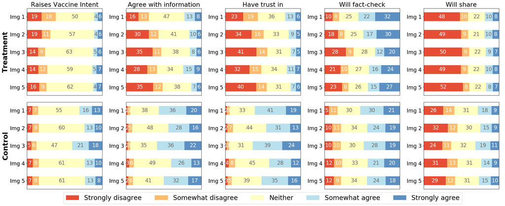

```python
ut.plot_image_perceptions([means_image_perceptions.loc['Treatment'], means_image_perceptions.loc['Control']], ['Treatment', 'Control'])
```

One interesting follow-up analysis is to use the self-reported image metrics as "features" of the images, to compute the contribution every image has in lowering the measured vaccine intent. Let us print the `stan` code for that model, run it for both treatment and control images, and infer the image weights. **This contributes to Supplementary Table 7 of the paper.**

```python
print(mo.model_image_impact(df, group=1, code_only=True))
```

```
                    data {
                        int<lower=1> n; //number of data points
                        int<lower=1> p; //number of images
                        int<lower=1> m; //number of metrics
                        int<lower=2> k; //number of outcomes
                        int<lower=1,upper=k> y_pre[n]; //pre-exposure
                        int<lower=1,upper=k> y_post[n]; //post-exposure
                        matrix[p,m] x_img[n]; //image metrics
                    }
                    parameters {
                        real beta;
                        vector[m] beta_img;
                        simplex[p] gamma;
                        simplex[k-1] delta;
                        ordered[k-1] alpha;
                    }
                    model {
                        beta ~ normal(0, 1.000000);
                        beta_img ~ normal(0, 1.000000);
                        {
                            vector[p] u_img;
                            for (i in 1:p)
                                u_img[i] = 1;
                            gamma ~ dirichlet(1.000000*u_img);
                        }
                        {
                            vector[k-1] u;
                            for (i in 1:(k-1))
                                u[i] = 1;
                            delta ~ dirichlet(1.000000*u);
                        }
                        alpha ~ normal(0, 1.000000);
                        for (i in 1:n)
                            y_post[i] ~ ordered_logistic(beta*sum(delta[:y_pre[i]-1]) + to_row_vector(gamma)*x_img[i]*beta_img, alpha);
                    }
```

```python
fit_image_impact_T = mo.model_image_impact(df, group=1)
```

```
INFO:pystan:COMPILING THE C++ CODE FOR MODEL anon_model_3e6de06cc1e81bd78d7e08f052878311 NOW.
```

```python
fit_image_impact_C = mo.model_image_impact(df, group=0)
```

```
INFO:pystan:COMPILING THE C++ CODE FOR MODEL anon_model_3e6de06cc1e81bd78d7e08f052878311 NOW.
```

```python
diags_image_impact_T = ut.stats(fit_image_impact_T, save=OUT_DIR+'6_%s_image_impact_T_diags'%COUNTRY)
stats_image_impact_T_or = ut.stats_image_impact(fit_image_impact_T, oddsratio=True, save=OUT_DIR+'6_%s_image_impact_T_stats_OR'%COUNTRY)
stats_image_impact_T_logor = ut.stats_image_impact(fit_image_impact_T, oddsratio=False, save=OUT_DIR+'6_%s_image_impact_T_stats_logOR'%COUNTRY)
diags_image_impact_C = ut.stats(fit_image_impact_C, save=OUT_DIR+'6_%s_image_impact_C_diags'%COUNTRY)
stats_image_impact_C_or = ut.stats_image_impact(fit_image_impact_C, oddsratio=True, save=OUT_DIR+'6_%s_image_impact_C_stats_OR'%COUNTRY)
stats_image_impact_C_logor = ut.stats_image_impact(fit_image_impact_C, oddsratio=False, save=OUT_DIR+'6_%s_image_impact_C_stats_logOR'%COUNTRY)
```

```python
ut.combine_dfs(stats_image_impact_T_logor, stats_image_impact_C_logor, 'Treatment', 'Control')
```

|  | Treatment mean | Treatment 2.5% | Treatment 97.5% | Control mean | Control 2.5% | Control 97.5% |
| --- | --- | --- | --- | --- | --- | --- |
| beta_img[1] | 0.702759 | 0.589533 | 0.821632 | 0.271712 | 0.031409 | 0.506377 |
| beta_img[2] | 0.047634 | -0.141875 | 0.250162 | -0.529766 | -0.963969 | -0.081496 |
| beta_img[3] | -0.002421 | -0.191143 | 0.177555 | -0.472792 | -0.879370 | -0.058430 |
| beta_img[4] | -0.036889 | -0.110113 | 0.039034 | -0.019698 | -0.188954 | 0.145869 |
| beta_img[5] | 0.153009 | 0.044996 | 0.259968 | 0.123368 | -0.034661 | 0.285899 |
| gamma[1] | 0.418596 | 0.282130 | 0.557757 | 0.410529 | 0.186181 | 0.643735 |
| gamma[2] | 0.281352 | 0.142217 | 0.421320 | 0.187212 | 0.012384 | 0.421479 |
| gamma[3] | 0.035154 | 0.001075 | 0.112037 | 0.182080 | 0.015312 | 0.393960 |
| gamma[4] | 0.107902 | 0.007769 | 0.244906 | 0.106837 | 0.004552 | 0.291993 |
| gamma[5] | 0.156996 | 0.023612 | 0.303938 | 0.113343 | 0.005391 | 0.285625 |

Observing $\gamma^g_k$'s, it appears that the first/third image in the misinformation set has the highest/lowest impact on reducing acceptance of a COVID-19 vaccine. Whereas the fourth image in the factual-information set has the lowest impact on reducing vaccine acceptance. A qualitative assessment of these images makes it evident that they have a scientific temperament, in terms of the semantic content. This could be indicative of scientific messaging having a bigger role to play than "memetic" information in swaying COVID-19 vaccine opinion.